# Bad habits vs Education

View Infographic PDF

View Presentation

This guided project explores whether there is a connection between the student population and "bad" habits or behaviors that may negatively impact health. The habits under study are:

- Coffee addiction
- Smoking
- Video game addiction

It is important to note that, due to a lack of recent research and available data on these topics, the data sources used in this project range from 2019 to 2020.

#### Slideshow controls:

*Press the `'↓'` key* when available on the bottom-right side of your screen.

*Press the `'→'` key* When `'↓'` is not available.

```python
import pandas as pd #For reading and handling CSV files.
import numpy as np  # For numerical operations and handling missing values.
import matplotlib.pyplot as plt  # For creating basic visualizations.
import seaborn as sns  # For advanced data visualization used in the infographic.
from IPython.display import Image, display, clear_output, HTML # Used to display images not generated in this notebook
from tabulate import tabulate # This beauty lets us create smooth table style outputs in terminal
import ipywidgets as widgets # This great tool lets use code into our notebook to make quick displays and customizations
from sklearn.preprocessing import MinMaxScaler #quick scalability
```

## Content:

1. Introduction.
2. Load Data.
3. Visualization Plan.
4. Loading & Cleaning Data

Also feel free to visit **https://github.com/DefoNotGus/DV_assesment** To find the project's notebook

### Is there a relationship between habits and education?

By examining the demographic factors associated with these habits and their prevalence in different cultures, the project aims to uncover potential links between these behaviors and the student population. Such insights could help society understand whether these harmful or misused habits are directly related to the stress faced by higher education students, highlighting the need to restructure education programs in regions where these addictions are more prevalent.

[figure not shown]

# Data Description.

## The datasets used to study the habits are:

1. **Coffee Consumption Dataset**: Lists coffee consumption by country with extensive coverage.
- **Source**: [Kaggle](https://www.kaggle.com/datasets/nurielreuven/coffee-consumption-by-country-2022/data)
- **Size**: 182 rows and 3 columns
- **Domain**: Healthcare and Marketing
2. **Smoking Rates Dataset**: Provides a chronological overview of smoking rates in many countries, sourced via a Google search.
- **Source**: [World Population Review](https://worldpopulationreview.com/country-rankings/smoking-rates-by-country)
- **Size**: 164 rows and 10 columns
- **Domain**: Healthcare
3. **Gamers Market Dataset**: Compiles 2019 gaming market overview in many countries, offering chronological alignment with the other datasets. Data Scraping techniques used.
- **Source**: [Allcorrect Games](https://allcorrectgames.com/insights/a-global-research-of-2019-games-market/)
- **Size**: 29 rows and 8 columns
- **Domain**: Marketing and Videogames

# Visualization Plan.

This project aims to generate a visual correlation between bad habits and education and analyze factors contributing to certain addictions using python as the tool for data handling. The approach involves, exploring and procesing data, Gathering the relevant data for visualization techniques. Creating an infographic that visually represents addiction patterns in relation to gender, geographic, and academic factors. Canva is the tool chosen for the design of the infographic and the draft.

## Key Variables:

- Country: Countries where the data was gathered, This will be our index for certain datasets.
- Coffee consumption per capita (2020): The amount of coffee divided by the population, basically the amount of coffee "per head" in Kilograms.
- Smokig Rates (2020): The porcentage of population that smokes of each country listed.
- Smokig Rates (2020) Male: The porcentage of male population that smokes of each country listed.
- Smokig Rates (2020)Female: The porcentage of female population that smokes of each country listed.
- Gamers (2019): The number of gamers per country in millions.
- Students per region (2020): Number of enrolled students per region.
- Students per country (2020): Number of enrolled students per Country.

## Visualizations:

Since the data to visualize is mainly comparative the plots to implement will be:

- Bar charts
- Line graphs
- Column charts
- Heatmaps
- Pie chart
- Stack bar chart
- Area chart

## Accesibility, Accuracy and presentation:

This project will follow up the following considerations to provide accesibility and avoid missleading data:

- Use readable fonts and sufficient text size.
- Include legends and labels for clarity and provide alternative text for charts.
- Ensure colorblind-friendly palettes (Only one graph has red-greens contrast, but the legend is there to help and guide).
- Normalize data for fair comparisons.
- Avoid cherry-picking data and present outliers and anomalies transparently.
- Clarify causation vs. correlation to avoid misinterpretation.
- Make the data and the code open source to enable users to make their own visualizations and research.
- Present a neat and clear format for the infographic like shown below (Click for fullscreen):

[figure not shown]

# Data Loading and Cleaning.

> The HTML.SLIDESHOW Version will only have snips of code. to see the full implementation check the notebook.

Datasets are loaded into variables using `pd.read_csv()` from the Pandas library.

```python
# Importing the CSV files
coffee_df = pd.read_csv('Datasets/coffee.csv')
smoking_df = pd.read_csv('Datasets/smoking.csv')
gamers_df = pd.read_csv('Datasets/gamers.csv')
edstats_df = pd.read_csv('Datasets/edstats.csv')
students_df = pd.read_csv('Datasets/students.csv')
```

## Display size and features.

Now we will display the size, features and data type of each dataframe using the methods `shape()` and `columns.tolist` and arranging them with `Tabulate` as shown below:

```python
# Prepare data for each dataframe using a list of title, shape and features.
data = [
    ["Coffee DataFrame", coffee_df.shape[0], coffee_df.shape[1], ", ".join(coffee_df.columns.tolist())],
    ["Smoking DataFrame", smoking_df.shape[0], smoking_df.shape[1], ", ".join(smoking_df.columns.tolist())],
    ["Gamers DataFrame", gamers_df.shape[0], gamers_df.shape[1], ", ".join(gamers_df.columns.tolist())],
    ["Students Enrollment DataFrame", edstats_df.shape[0], edstats_df.shape[1], ", ".join(edstats_df.columns.tolist())],
    ["Students Enrollment by Country DataFrame", students_df.shape[0], students_df.shape[1], ", ".join(students_df.columns.tolist())]
]
# Define the table headers
headers = ["DataFrame", "Rows", "Columns", "Features"]
# Generate HTML table using tabulate
table_html = tabulate(data, headers=headers, tablefmt="html")
# Wrap the table in a div to scale it down and enable scrolling
scaled_table_html = f'''
<div style=" max-height: 400px; overflow: auto;">
    {table_html}
</div>
'''
```

```python
# Display the scaled and scrollable HTML table
HTML(scaled_table_html)
```

| DataFrame | Rows | Columns | Features |
| --- | --- | --- | --- |
| Coffee DataFrame | 182 | 3 | country, coffeeConsumptionByCountry_perCapitaCons2020, coffeeConsumptionByCountry_perCapitaCons2016 |
| Smoking DataFrame | 164 | 10 | country, smokingRatesByCountry_rateBothPct2022, smokingRatesByCountry_rateMalePct2022, smokingRatesByCountry_rateFemalePct2022, smokingRatesByCountry_rateBothPct2021, smokingRatesByCountry_rateMalePct… |
| Gamers DataFrame | 29 | 8 | №, Country, Games Market Revenue (mln USD), Internet Penetration (%), Number of Gamers (millions), Mobile Market (mln USD), Average Yearly Spending on Mobile Games (USD), EF EPI (English Proficiency I… |
| Students Enrollment DataFrame | 197235 | 8 | Series, Series Code, Country Name, Country Code, 2019 [YR2019], 2020 [YR2020], 2021 [YR2021], 2022 [YR2022] |
| Students Enrollment by Country DataFrame | 52 | 26 | STRUCTURE, STRUCTURE_ID, STRUCTURE_NAME, ACTION, LOCATION, Country, INDICATOR, Indicator, SUBJECT, Subject, MEASURE, Measure, FREQUENCY, Frequency, TIME_PERIOD, Time, OBS_VALUE, Observation Value, OBS… |

# Peeking in Our Data

Using `ipywidgets`(library), `Tabulate`, `.head()` and `tail()` (`Pandas` functions) we will display a small version of how every table looks like for error handling purposes.

> `ipywidgets` Only available in Jupyter Notebook version

```python
descriptions = {
    "coffee": "This dataset lists 183 countries' coffee consumption per capita (in kg) for 2020 and 2016, highlighting high-consumption countries.",
    "smoking": "This dataset shows smoking rates by gender in 164 countries (2020–2022), enabling comparisons by country and gender.",
    "gamers": "This dataset covers 29 countries, including gaming revenue, internet penetration, gamer count, mobile market stats, and English proficiency, making it ideal for analyzing gamers by country.",
    "edstats": "This dataset contains extensive data collected per series, not just by country. For this project, we'll focus on analyzing higher education populations by filtering the relevant series.",
    "students": "This dataset shows specific information gathered from a list of selected countries in other datasets. it shows the students enrolment data per level (primary, secundary, terciary and total)."
}

# Create the Output widget to display the dataframes and descriptions
output = widgets.Output(
    layout=widgets.Layout(
        max_height="400px", overflow="auto"  # Enables both vertical and horizontal scrolling
    )
)

# Create text input widgets for the user to specify head and tail rows
head_input = widgets.IntText(value=5, description='Head Rows:', min=1)
tail_input = widgets.IntText(value=5, description='Tail Rows:', min=1)

# Function to display head, tail, and description of the dataframe based on user input
def display_head_tail(df, description, head_rows, tail_rows):
    with output:
        clear_output(wait=True)  # Clears previous output
        # Display the description as HTML
        display(widgets.HTML(f"<b>{description}</b><br>"))  # Display the description
        # Convert the dataframe to HTML and display it
        display(HTML(df.head(head_rows).to_html()))
        display(HTML(df.tail(tail_rows).to_html()))

# Create the buttons
coffee_button = widgets.Button(description="Coffee Data")
smoking_button = widgets.Button(description="Smoking Data")
gamers_button = widgets.Button(description="Gamers Data")
edstats_button = widgets.Button(description="Education Stats")
students_button = widgets.Button(description="Students Data")

# Function to handle button clicks
def on_button_click(button):
    # Get the values from the head and tail inputs
    head_rows = head_input.value
    tail_rows = tail_input.value

    if button == coffee_button:
        display_head_tail(coffee_df, descriptions["coffee"], head_rows, tail_rows)
    elif button == smoking_button:
        display_head_tail(smoking_df, descriptions["smoking"], head_rows, tail_rows)
    elif button == gamers_button:
        display_head_tail(gamers_df, descriptions["gamers"], head_rows, tail_rows)
    elif button == edstats_button:
        display_head_tail(edstats_df, descriptions["edstats"], head_rows, tail_rows)
    elif button == students_button:
        display_head_tail(students_df, descriptions["students"], head_rows, tail_rows)

# Attach the function to each button
coffee_button.on_click(on_button_click)
smoking_button.on_click(on_button_click)
gamers_button.on_click(on_button_click)
edstats_button.on_click(on_button_click)
students_button.on_click(on_button_click)

# Layout for horizontal alignment of buttons
buttons = widgets.HBox([coffee_button, smoking_button, gamers_button, edstats_button, students_button])
# Display the input widgets, buttons, and the output area
display(widgets.VBox([widgets.HBox([head_input, tail_input]), buttons, output]))
```

```
VBox(children=(HBox(children=(IntText(value=5, description='Head Rows:'), IntText(value=5, description='Tail R…
```

The code below is used for improving the GUI in HTML version.

```python
#Function to gather an specific amount of tail and head from a dataframe
def display_df_head_tail(df, num_rows=5):
    # Get the head and tail of the DataFrame
    head = df.head(num_rows).to_html(classes='table table-bordered table-striped')
    tail = df.tail(num_rows).to_html(classes='table table-bordered table-striped')
# Combine head and tail into a single HTML output with styled scrolling container
    return f'''
    <style>
        .scrollable {{
            max-height: 250px;
            overflow: auto;
        }}
    </style>
    <h4>First {num_rows} rows (Head) of the selected DataFrame</h4>
    <div class="scrollable">
        {head}
    </div>
    <h4>Last {num_rows} rows (Tail) of the selected DataFrame</h4>
    <div class="scrollable">
        {tail}
    </div>
    '''
```

```python
#Coffee
display(HTML(display_df_head_tail(coffee_df)))
```

First 5 rows (Head) of the selected DataFrame

|  | country | coffeeConsumptionByCountry_perCapitaCons2020 | coffeeConsumptionByCountry_perCapitaCons2016 |
| --- | --- | --- | --- |
| 0 | Albania | 4.51 | NaN |
| 1 | Algeria | 0.97 | NaN |
| 2 | Angola | 0.33 | NaN |
| 3 | Antigua and Barbuda | 6.07 | NaN |
| 4 | Argentina | 2.32 | NaN |

Last 5 rows (Tail) of the selected DataFrame

|  | country | coffeeConsumptionByCountry_perCapitaCons2020 | coffeeConsumptionByCountry_perCapitaCons2016 |
| --- | --- | --- | --- |
| 177 | Venezuela | 1.86 | NaN |
| 178 | Vietnam | 5.77 | NaN |
| 179 | Yemen | 0.59 | NaN |
| 180 | Zambia | 0.09 | NaN |
| 181 | Zimbabwe | 0.15 | NaN |

### coffee_df

```python
#smoking
display(HTML(display_df_head_tail(smoking_df)))
```

First 5 rows (Head) of the selected DataFrame

|  | country | smokingRatesByCountry_rateBothPct2022 | smokingRatesByCountry_rateMalePct2022 | smokingRatesByCountry_rateFemalePct2022 | smokingRatesByCountry_rateBothPct2021 | smokingRatesByCountry_rateMalePct2021 | smokingRatesByCountry_rateFemalePct2021 | smokingRatesByCountry_rateBothPct2020 | smokingRatesByCountry_rateMalePct2020 | smokingRatesByCountry_rateFemalePct2020 |
| --- | --- | --- | --- | --- | --- | --- | --- | --- | --- | --- |
| 0 | India | 24.3 | 37.8 | 10.8 | 25.2 | 38.8 | 11.5 | 26.1 | 40.0 | 12.2 |
| 1 | China | 23.4 | 45.1 | 1.6 | 23.4 | 45.2 | 1.6 | 23.7 | 45.6 | 1.7 |
| 2 | United States | 24.3 | 29.9 | 18.7 | 24.7 | 30.4 | 18.9 | 24.9 | 30.6 | 19.3 |
| 3 | Indonesia | 38.2 | 73.1 | 3.3 | 37.9 | 72.4 | 3.4 | 37.8 | 72.1 | 3.6 |
| 4 | Pakistan | 18.9 | 30.8 | 7.0 | 19.5 | 31.7 | 7.3 | 20.2 | 32.8 | 7.7 |

Last 5 rows (Tail) of the selected DataFrame

|  | country | smokingRatesByCountry_rateBothPct2022 | smokingRatesByCountry_rateMalePct2022 | smokingRatesByCountry_rateFemalePct2022 | smokingRatesByCountry_rateBothPct2021 | smokingRatesByCountry_rateMalePct2021 | smokingRatesByCountry_rateFemalePct2021 | smokingRatesByCountry_rateBothPct2020 | smokingRatesByCountry_rateMalePct2020 | smokingRatesByCountry_rateFemalePct2020 |
| --- | --- | --- | --- | --- | --- | --- | --- | --- | --- | --- |
| 159 | Marshall Islands | 29.8 | 51.2 | 8.5 | 29.7 | 51.0 | 8.5 | 29.6 | 50.7 | 8.6 |
| 160 | Palau | 17.3 | 27.1 | 7.6 | 17.7 | 27.6 | 7.8 | 18.0 | 27.9 | 8.0 |
| 161 | Cook Islands | 27.0 | 31.8 | 22.2 | 27.4 | 32.3 | 22.6 | 27.9 | 32.9 | 23.0 |
| 162 | Nauru | 48.3 | 48.6 | 48.1 | 48.9 | 49.0 | 48.7 | 49.4 | 49.2 | 49.5 |
| 163 | Tuvalu | 33.7 | 48.2 | 19.1 | 34.2 | 48.9 | 19.4 | 34.8 | 50.0 | 19.7 |

### smoking_df

- Default numeric index
- All the columns (except country) seem to be in float type.
- Does not appear to have either missing or invalid data

```python
# Gamers
display(HTML(display_df_head_tail(gamers_df)))
```

First 5 rows (Head) of the selected DataFrame

|  | № | Country | Games Market Revenue (mln USD) | Internet Penetration (%) | Number of Gamers (millions) | Mobile Market (mln USD) | Average Yearly Spending on Mobile Games (USD) | EF EPI (English Proficiency Index) |
| --- | --- | --- | --- | --- | --- | --- | --- | --- |
| 0 | 1 | China | 36,540 | 59.30% | 640 | 21,140 | 14.69 | 53.44 (Moderate) |
| 1 | 2 | United States | 36,500 | 86.50% | 215.15 | 9,937 | 30.02 | 100.00 (Native) |
| 2 | 3 | Japan | 18,683 | 93.20% | 79.6 | 6,528.40 | 51.65 | 51.51 (Low) |
| 3 | 4 | South Korea | 6,194 | 86.50% | 41.9 | 5,810 | 113.48 | 55.04 (Moderate) |
| 4 | 5 | Germany | 6,000 | 94.50% | 58.59 | 606.3 | 7.24 | 63.77 (Very High) |

Last 5 rows (Tail) of the selected DataFrame

|  | № | Country | Games Market Revenue (mln USD) | Internet Penetration (%) | Number of Gamers (millions) | Mobile Market (mln USD) | Average Yearly Spending on Mobile Games (USD) | EF EPI (English Proficiency Index) |
| --- | --- | --- | --- | --- | --- | --- | --- | --- |
| 24 | 25 | Iran | 458 | 80.50% | 30 | 198 | 2.36 | 48.69 (Low) |
| 25 | 26 | United Arab Emirates | 342 | 99% | 7.84 | 78.7 | 8.03 | 48.19 (Very Low) |
| 26 | 27 | Singapore | 319 | 84% | 4.8 | 52 | 8.97 | 66.82 (Very High) |
| 27 | 28 | South Africa | 224.58 | 67.70% | 50.9 | 43.6 | 0.74 | 65.38 (Very High) |
| 28 | 29 | Nigeria | 85 | 61.10% | – | 56 | 0.27 | 58.26 (High) |

### gamers_df

```python
# Education Stats
display(HTML(display_df_head_tail(edstats_df)))
```

First 5 rows (Head) of the selected DataFrame

|  | Series | Series Code | Country Name | Country Code | 2019 [YR2019] | 2020 [YR2020] | 2021 [YR2021] | 2022 [YR2022] |
| --- | --- | --- | --- | --- | --- | --- | --- | --- |
| 0 | Labor force with advanced education, male (% of male labor force) | SL.TLF.ADVN.MA.ZS | Afghanistan | AFG | .. | .. | .. | .. |
| 1 | Labor force with advanced education, male (% of male labor force) | SL.TLF.ADVN.MA.ZS | Albania | ALB | .. | .. | .. | .. |
| 2 | Labor force with advanced education, male (% of male labor force) | SL.TLF.ADVN.MA.ZS | Algeria | DZA | .. | .. | .. | .. |
| 3 | Labor force with advanced education, male (% of male labor force) | SL.TLF.ADVN.MA.ZS | American Samoa | ASM | .. | .. | .. | .. |
| 4 | Labor force with advanced education, male (% of male labor force) | SL.TLF.ADVN.MA.ZS | Andorra | AND | .. | .. | .. | .. |

Last 5 rows (Tail) of the selected DataFrame

|  | Series | Series Code | Country Name | Country Code | 2019 [YR2019] | 2020 [YR2020] | 2021 [YR2021] | 2022 [YR2022] |
| --- | --- | --- | --- | --- | --- | --- | --- | --- |
| 197230 | NaN | NaN | NaN | NaN | NaN | NaN | NaN | NaN |
| 197231 | NaN | NaN | NaN | NaN | NaN | NaN | NaN | NaN |
| 197232 | NaN | NaN | NaN | NaN | NaN | NaN | NaN | NaN |
| 197233 | Data from database: Education Statistics - All Indicators | NaN | NaN | NaN | NaN | NaN | NaN | NaN |
| 197234 | Last Updated: 06/25/2024 | NaN | NaN | NaN | NaN | NaN | NaN | NaN |

### edstats_df

- Huge DataFrame
- Lots of NaN (probaby corrupted or wrong data)
- The information will have to be filter by series as each series happens to have countries data.
- Lots of ".." (empty data)

```python
# Education Stats
display(HTML(display_df_head_tail(students_df)))
```

First 5 rows (Head) of the selected DataFrame

|  | STRUCTURE | STRUCTURE_ID | STRUCTURE_NAME | ACTION | LOCATION | Country | INDICATOR | Indicator | SUBJECT | Subject | MEASURE | Measure | FREQUENCY | Frequency | TIME_PERIOD | Time | OBS_VALUE | Observation Value | OBS_STATUS | Observation Status | UNIT_MEASURE | Unit of Measures | UNIT_MULT | Multiplier | BASE_PER | Base reference period |
| --- | --- | --- | --- | --- | --- | --- | --- | --- | --- | --- | --- | --- | --- | --- | --- | --- | --- | --- | --- | --- | --- | --- | --- | --- | --- | --- |
| 0 | DATAFLOW | OECD:DF_DP_LIVE(1.0) | OECD Data Archive | I | FRA | France | STUDENT | Number of students | TRY | Tertiary | IDX2015 | 2015=100 | A | Annual | 2020 | NaN | 113.34500 | NaN | A | NaN | NaN | NaN | NaN | NaN | NaN | NaN |
| 1 | DATAFLOW | OECD:DF_DP_LIVE(1.0) | OECD Data Archive | I | DEU | Germany | STUDENT | Number of students | PRY | Primary | IDX2015 | 2015=100 | A | Annual | 2020 | NaN | 104.62360 | NaN | A | NaN | NaN | NaN | NaN | NaN | NaN | NaN |
| 2 | DATAFLOW | OECD:DF_DP_LIVE(1.0) | OECD Data Archive | I | ITA | Italy | STUDENT | Number of students | PRY_NTRY | Primary to post-secondary non-tertiary | IDX2015 | 2015=100 | A | Annual | 2020 | NaN | 98.49902 | NaN | A | NaN | NaN | NaN | NaN | NaN | NaN | NaN |
| 3 | DATAFLOW | OECD:DF_DP_LIVE(1.0) | OECD Data Archive | I | KOR | Korea | STUDENT | Number of students | PRY_NTRY | Primary to post-secondary non-tertiary | IDX2015 | 2015=100 | A | Annual | 2020 | NaN | 87.87145 | NaN | A | NaN | NaN | NaN | NaN | NaN | NaN | NaN |
| 4 | DATAFLOW | OECD:DF_DP_LIVE(1.0) | OECD Data Archive | I | ESP | Spain | STUDENT | Number of students | ALLLEVEL | All levels | IDX2015 | 2015=100 | A | Annual | 2020 | NaN | 104.24360 | NaN | A | NaN | NaN | NaN | NaN | NaN | NaN | NaN |

Last 5 rows (Tail) of the selected DataFrame

|  | STRUCTURE | STRUCTURE_ID | STRUCTURE_NAME | ACTION | LOCATION | Country | INDICATOR | Indicator | SUBJECT | Subject | MEASURE | Measure | FREQUENCY | Frequency | TIME_PERIOD | Time | OBS_VALUE | Observation Value | OBS_STATUS | Observation Status | UNIT_MEASURE | Unit of Measures | UNIT_MULT | Multiplier | BASE_PER | Base reference period |
| --- | --- | --- | --- | --- | --- | --- | --- | --- | --- | --- | --- | --- | --- | --- | --- | --- | --- | --- | --- | --- | --- | --- | --- | --- | --- | --- |
| 47 | DATAFLOW | OECD:DF_DP_LIVE(1.0) | OECD Data Archive | I | GBR | United Kingdom | STUDENT | Number of students | ALLLEVEL | All levels | IDX2015 | 2015=100 | A | Annual | 2020 | NaN | 99.19232 | NaN | A | NaN | NaN | NaN | NaN | NaN | NaN | NaN |
| 48 | DATAFLOW | OECD:DF_DP_LIVE(1.0) | OECD Data Archive | I | GBR | United Kingdom | STUDENT | Number of students | PRY | Primary | IDX2015 | 2015=100 | A | Annual | 2020 | NaN | 104.34020 | NaN | A | NaN | NaN | NaN | NaN | NaN | NaN | NaN |
| 49 | DATAFLOW | OECD:DF_DP_LIVE(1.0) | OECD Data Archive | I | GBR | United Kingdom | STUDENT | Number of students | TRY | Tertiary | IDX2015 | 2015=100 | A | Annual | 2020 | NaN | 115.78140 | NaN | A | NaN | NaN | NaN | NaN | NaN | NaN | NaN |
| 50 | DATAFLOW | OECD:DF_DP_LIVE(1.0) | OECD Data Archive | I | IND | India | STUDENT | Number of students | TRY | Tertiary | IDX2015 | 2015=100 | A | Annual | 2020 | NaN | 113.34730 | NaN | A | NaN | NaN | NaN | NaN | NaN | NaN | NaN |
| 51 | DATAFLOW | OECD:DF_DP_LIVE(1.0) | OECD Data Archive | I | CAN | Canada | STUDENT | Number of students | ALLLEVEL | All levels | IDX2015 | 2015=100 | A | Annual | 2020 | NaN | 105.69040 | NaN | A | NaN | NaN | NaN | NaN | NaN | NaN | NaN |

### students_df:

- Too many features, Some are irrelevant for visualization (e.g. "STRUCTURE" and "STRUCTURE_ID").
- Two Subject columns "SUBJECT" and "Subject"
- Lots of NaN, But luckily its mostly on irrelevant features

# Processing Data:

We will progresively remove or handle missing values, correcting or convert data types accurately, filtering out unnecessary rows or columns, transforming data by normalizing, scaling, or aggregating to ensure consistency and usability.

## Coffee_df:

Now to process this dataset, we will do the following in a new variable called **coffee2020_df**:

1. Remove unnecessary features, specifically the 2016 data.
2. Rename columns to give them clearer titles.
3. Remove rows with missing values using `.dropna()`.
4. Change data type when needed, as by default is often adopted "string" type.
5. Set 'Country' as the dataset index.
6. Using `.isin()` check for empty values.
7. Display new features and changes in size of the DF.

The main reason for keeping only the 2020 information is to perform a country-to-country analysis within the same year.

```python
coffee2020_df = (coffee_df
    .drop(columns=['coffeeConsumptionByCountry_perCapitaCons2016'])  # Drop unnecessary column
    .rename(columns={'coffeeConsumptionByCountry_perCapitaCons2020': 'Coffee per capita in 2020 (KG)',
                     'country': 'Country'})  # Rename columns
    .dropna()  # Remove rows with missing values
)
coffee2020_df = coffee2020_df[coffee2020_df['Coffee per capita in 2020 (KG)'] != 0]  # Remove rows with '0'
coffee2020_df['Coffee per capita in 2020 (KG)'] = coffee2020_df['Coffee per capita in 2020 (KG)'].astype(float)
coffee2020_df.set_index('Country', inplace=True)  # Set index

missing_or_empty_values = coffee2020_df.isin(['', None]).sum().sum()
print(f"Current missing or empty values: {missing_or_empty_values}")
print("Features in coffee2020_df:", coffee2020_df.columns.tolist())

row_diff, col_diff = coffee_df.shape[0] - coffee2020_df.shape[0], coffee_df.shape[1] - coffee2020_df.shape[1]
print(f"Difference in rows: {row_diff}\nDifference in columns: {col_diff}\n Remember Country is now index ☻")
```

```
Current missing or empty values: 0
Features in coffee2020_df: ['Coffee per capita in 2020 (KG)']
Difference in rows: 3
Difference in columns: 2
 Remember Country is now index ☻
```

We removed one feature, converted country in our index and deleted 3 rows for missing data.

## Smoking_df

Similary, it's needed to create a new varaible called **smoking2020_df**:

1. Remove unnecessary features, all the data from 2022 and 2021.
2. Rename columns to give them clearer titles.
3. Change data type when neededto interger.
4. Remove missing values or empty strings per row.
5. Set 'Country' as the dataset index.
6. Check the changes where made properly

```python
smoking2020_df = (smoking_df[['country', 'smokingRatesByCountry_rateBothPct2020',
                              'smokingRatesByCountry_rateMalePct2020',
                              'smokingRatesByCountry_rateFemalePct2020']]
    .rename(columns={
        'country': 'Country',
        'smokingRatesByCountry_rateBothPct2020': 'Smoking rate in 2020(%)',
        'smokingRatesByCountry_rateMalePct2020': 'Male smoking rate in 2020(%)',
        'smokingRatesByCountry_rateFemalePct2020': 'Female smoking rate in 2020(%)'
    })
    .replace(['', '0'], np.nan)
    .dropna()
)
smoking2020_df[['Smoking rate in 2020(%)', 'Male smoking rate in 2020(%)',
                'Female smoking rate in 2020(%)']] = smoking2020_df[
    ['Smoking rate in 2020(%)', 'Male smoking rate in 2020(%)', 'Female smoking rate in 2020(%)']
].apply(pd.to_numeric, errors='coerce')
smoking2020_df.set_index('Country', inplace=True)

missing_or_empty_values = smoking2020_df.isin(['', None]).sum().sum()
print(f"Current missing or empty values: {missing_or_empty_values}")
print("Features in smoking2020_df:", smoking2020_df.columns.tolist())

row_diff, col_diff = smoking_df.shape[0] - smoking2020_df.shape[0], smoking_df.shape[1] - smoking2020_df.shape[1]
print(f"Difference in rows: {row_diff}\nDifference in columns: {col_diff}")
```

```
Current missing or empty values: 0
Features in smoking2020_df: ['Smoking rate in 2020(%)', 'Male smoking rate in 2020(%)', 'Female smoking rate in 2020(%)']
Difference in rows: 1
Difference in columns: 7
```

Succesfully we dropped 6 columns, "coutry" was not dropped but taken as index. And we removed a row for invalid value.

### Gamers_df:

We will process the gamers_df dataset similarly, creatign a new dataframe, *gamers2019_df*, performing the following tasks:

1. Remove unnecessary columns.
2. Rename columns to give them clearer titles.
3. Convert relevant columns to the correct data type.
4. Remove rows with missing or incorrect data.
5. Set 'Country' as the dataset index.

```python
gamers2019_df = gamers_df[['Country', 'Number of Gamers (millions)']] \
    .rename(columns={'Number of Gamers (millions)': 'Gamers in 2019(MM)'}) \
    .assign(**{'Gamers in 2019(MM)': lambda x: pd.to_numeric(x['Gamers in 2019(MM)'], errors='coerce')}) \
    .dropna() \
    .set_index('Country')

missing_or_empty_values = gamers2019_df.isnull().sum().sum() + (gamers2019_df == '').sum().sum()
print(f"Missing or empty values: {missing_or_empty_values}")
print("Features:", gamers2019_df.columns.tolist())

row_diff, col_diff = gamers_df.shape[0] - gamers2019_df.shape[0], gamers_df.shape[1] - gamers2019_df.shape[1]
print(f"Row diff: {row_diff}, Col diff: {col_diff}")
```

```
Missing or empty values: 0
Features: ['Gamers in 2019(MM)']
Row diff: 1, Col diff: 7
```

## EdStats:

requires a more complex approach. First, determine which "Series" to filter before standard processing. Create an "enrolment_df" by using the str.contains() method to filter rows where the "Series" column contains the word "enrolment." Use the unique() method to display all unique values in the "Series" column.

```python
unique_enrolment_df = edstats_df['Series'][edstats_df['Series'].str.contains('enrolment', case=False, na=False)].unique()
html_content = f"""
<div style="max-height: 250px; overflow-y: auto; border: 1px solid #ccc; padding: 10px;">
    {''.join(f'<p>{item}</p>' for item in unique_enrolment_df)}</div>"""
display(HTML(html_content))
```

Percentage of enrolment in tertiary education in private institutions (%)

Total net enrolment rate, lower secondary, both sexes (%)

Total net enrolment rate, lower secondary, female (%)

Total net enrolment rate, lower secondary, gender parity index (GPI)

Total net enrolment rate, lower secondary, male (%)

Total net enrolment rate, primary, both sexes (%)

Total net enrolment rate, primary, female (%)

Total net enrolment rate, primary, gender parity index (GPI)

Total net enrolment rate, primary, male (%)

Total net enrolment rate, upper secondary, both sexes (%)

Total net enrolment rate, upper secondary, female (%)

Total net enrolment rate, upper secondary, gender parity index (GPI)

Total net enrolment rate, upper secondary, male (%)

Enrolment in post-secondary non-tertiary education, both sexes (number)

Enrolment in post-secondary non-tertiary education, female (number)

Enrolment in post-secondary non-tertiary education, male (number)

Enrolment in tertiary education, all programmes, both sexes (number)

Enrolment in tertiary education, all programmes, female (number)

Enrolment in tertiary education, all programmes, male (number)

From this information we can conclude that we want the following series only: 'Enrolment in tertiary education, all programmes, both sexes (number)'

Now we proceed to:

1. Remove unnecessary rows (All th rows with irrelevant information).
2. Rename columns to give them clearer titles.
3. Remove unnecessary columns (We will only keep Country and the year 2020)
4. Remove rows with missing or incorrect data.
5. Convert relevant columns to the correct data type.
6. Create a new column that handles the both years (2019 and 2020) prioritizing the most recent.
7. Drop rows without numeric data in either 2019 and 2020.
8. Set 'Country' as the dataset index.

```python
edstats2020_df = edstats_df[edstats_df['Series'] == 'Enrolment in tertiary education, all programmes, both sexes (number)'] \
    .rename(columns={'Country Name': 'Region', '2020 [YR2020]': 'Students in 2020', '2019 [YR2019]': 'Students in 2019'}) \
    [['Region', 'Students in 2020', 'Students in 2019']]

edstats2020_df['Students in 2020'] = pd.to_numeric(edstats2020_df['Students in 2020'].replace(r'[^0-9]', '', regex=True), errors='coerce').astype('Int64')
edstats2020_df['Students in 2019'] = pd.to_numeric(edstats2020_df['Students in 2019'].replace(r'[^0-9]', '', regex=True), errors='coerce').astype('Int64')
edstats2020_df['Students in 2019-20'] = edstats2020_df['Students in 2020'].combine_first(edstats2020_df['Students in 2019'])

edstats2020_df = edstats2020_df[['Region', 'Students in 2019-20']].dropna(subset=['Students in 2019-20']).set_index('Region')
print(f"Size: Rows: {edstats2020_df.shape[0]}, Columns: {edstats2020_df.shape[1]}")
```

```
Size: Rows: 75, Columns: 1
```

Something very peculiar about this World Bank Groups dataset is the fact that it does not provide only countries but also regions. Therefore we will list all the 'regions' available and then we will proceed to create a data map after carefully choosing each countries most accurate equivalent. Better explained in the merging section.

```python
unique_regions = edstats2020_df.index.unique()
html_content = f"""<div style="max-height: 250px; overflow-y: auto; border: 1px solid #ccc; padding: 10px;">
    <h4>Unique Regions in edstats2020_df:</h4>
    {''.join(f'<p>{region}</p>' for region in unique_regions)}</div>"""
display(HTML(html_content))
```

Unique Regions in edstats2020_df:

Albania

Andorra

Arab World

Armenia

Azerbaijan

Bahrain

Bangladesh

Belize

Bhutan

Bosnia and Herzegovina

Botswana

Brunei Darussalam

Burkina Faso

Cambodia

China

Costa Rica

East Asia & Pacific

East Asia & Pacific (excluding high income)

Euro area

Europe & Central Asia

Europe & Central Asia (excluding high income)

European Union

Georgia

Ghana

Heavily indebted poor countries (HIPC)

High income

Hong Kong SAR, China

India

Kazakhstan

Kuwait

Kyrgyz Republic

Lao PDR

Latin America & Caribbean

Latin America & Caribbean (excluding high income)

Least developed countries: UN classification

Lebanon

Low & middle income

Lower middle income

Macao SAR, China

Malaysia

Marshall Islands

Mauritania

Middle East & North Africa

Middle East & North Africa (excluding high income)

Middle income

Moldova

Monaco

Montenegro

Morocco

Nepal

Niger

North America

OECD members

Oman

Qatar

Rwanda

San Marino

Saudi Arabia

Senegal

Serbia

Seychelles

South Africa

South Asia

Sri Lanka

St. Lucia

Tanzania

Togo

Tunisia

Turkmenistan

Ukraine

Upper middle income

Uzbekistan

Viet Nam

West Bank and Gaza

World

## Students_df

From this table all we want to do is pick the 'Country' and 'Subject' Column, where Subject is equal to 'Terciary' which stands for University and Higher Education.

1. Drop unwanted columns
2. Drop rows without "Tertiary" Subject.
3. Drop NaN data.
4. Make 'Country' an index
5. Print size

```python
students2020_df = students_df.loc[students_df['Subject'] == 'Tertiary', ['Country', 'OBS_VALUE']] \
    .dropna() \
    .rename(columns={'OBS_VALUE': 'Students in 2019-20'}) \
    .set_index('Country')

print(f"Size of students2020_df: {students2020_df.shape[0]} rows, {students2020_df.shape[1]} columns")
```

```
Size of students2020_df: 13 rows, 1 columns
```

## Merging tables

we will merge "coffee2020_df", "smoking2020_df" and "gamers2019_df" into one single data frame called **"habits2020_df"**.

```python
# Merge the DataFrames on 'Country' without including edstats2020_df
habits2020_df = smoking2020_df.join(gamers2019_df, how='inner', rsuffix='_gamers')
habits2020_df = habits2020_df.join(coffee2020_df, how='inner', rsuffix='_coffee')

# Display the size of the resulting DataFrame
print("Size of habits2020_df:", habits2020_df.shape)
```

```
Size of habits2020_df: (23, 5)
```

As mentioned before, edstats_df does not have a 'Country' column but a 'Region' instead, in order to merge smoothly this two datasets into a single "HABITS VS EDUCATION" dataframe. We need to add a 'Region' column to habits2020_df and assign logical values from the "unique_regions" list created before.

To achieve this we have made manually a map, When possible we will use the already existing Country for example, China and South Africa. otherwise we allocated it by simple proximity.

```python
country_to_region_mapping = {
    'China': 'China',
    'South Africa': 'South Africa',
    'North America': ['United States', 'Canada'],
    'East Asia & Pacific': [
        'Indonesia', 'Japan', 'Philippines', 'Vietnam',
        'Thailand', 'South Korea', 'Australia'
    ],
    'Latin America & Caribbean': ['Brazil'],
    'Europe & Central Asia': [
        'Russia', 'Turkey', 'Germany', 'United Kingdom',
        'France', 'Italy', 'Spain', 'Poland'
    ],
    'Middle East & North Africa': [
        'Iran', 'Saudi Arabia', 'United Arab Emirates'
    ]
}

country_to_region_mapping = {
    country: region
    for region, countries in country_to_region_mapping.items()
    for country in ([countries] if isinstance(countries, str) else countries)
}
```

Now we use the map to create our 'Region' Column in a new temporal dataframe called **"habits2020_REG"**

```python
habits2020_REG = habits2020_df.copy()
# * Using a self made map. Each individual row gets assigned different a Region
habits2020_REG['Region'] = habits2020_REG.index.map(country_to_region_mapping)
habits2020_REG = habits2020_REG.groupby('Region').mean().reset_index().set_index('Region')

print("Size of habits2020_REG:", habits2020_REG.shape)
```

```
Size of habits2020_REG: (7, 5)
```

# habits_vs_education_df:

Now we will merge habits2020_REG with edstats2020_df using Region as the index and merge habits2020_df with students2020_df to get two tables, we will call them region_df and country_df

```python
region_df = habits2020_REG.merge(edstats2020_df, left_index=True, right_index=True)
display(HTML(f"""
<div style="max-height: 250px; overflow-y: auto; border: 1px solid #ccc; padding: 10px;">
    <h4>First row of region_df:</h4><pre>{region_df.head(1).to_html()}</pre>
    <h4>Size of region_df:</h4><pre>{region_df.shape}</pre>
    <h4>Unique Index Values:</h4><pre>{region_df.index.unique()}</pre></div>"""))
```

First row of region_df:

```
      Smoking rate in 2020(%)
      Male smoking rate in 2020(%)
      Female smoking rate in 2020(%)
      Gamers in 2019(MM)
      Coffee per capita in 2020 (KG)
      Students in 2019-20


      Region










      China
      23.7
      45.6
      1.7
      640.0
      0.29
      46993614
```

Size of region_df:

```
(7, 6)
```

Unique Index Values:

```
Index(['China', 'East Asia & Pacific', 'Europe & Central Asia',
       'Latin America & Caribbean', 'Middle East & North Africa',
       'North America', 'South Africa'],
      dtype='object', name='Region')
```

```python
# Merge habits2020_df and students2020_df using "Country" as index
country_df = pd.merge(habits2020_df, students2020_df, left_index=True, right_index=True)

# Display the resulting merged DataFrame
display(HTML(f"""
<div style="max-height: 250px; overflow-y: auto; border: 1px solid #ccc; padding: 10px;">
    <h4>First row of country_df:</h4><pre>{country_df.head(1).to_html()}</pre>
    <h4>Size of country_df:</h4><pre>{country_df.shape}</pre>
    <h4>Unique Index Values:</h4><pre>{country_df.index.unique()}</pre></div>"""))
```

First row of country_df:

```
      Smoking rate in 2020(%)
      Male smoking rate in 2020(%)
      Female smoking rate in 2020(%)
      Gamers in 2019(MM)
      Coffee per capita in 2020 (KG)
      Students in 2019-20


      Country










      United States
      24.9
      30.6
      19.3
      215.15
      4.71
      96.48482
```

Size of country_df:

```
(10, 6)
```

Unique Index Values:

```
Index(['United States', 'Germany', 'United Kingdom', 'France', 'South Africa',
       'Italy', 'Spain', 'Canada', 'Poland', 'Australia'],
      dtype='object', name='Country')
```

## DATA VIZUALIZATION (Advice to explore in Notebook version)

### Comparison of smokers consumption by gender per region

In order to organize this data we will first create a table called 'fig1_df' which will hold only *Male smoking rate in 2020(%)* and *Female smoking rate in 2020(%)*. Then we will simplify the names, create a figure and create the bars and stack 'Female Smoking Rate' bar on top of the 'Male Smoking Rate' bar to create a visual effect of a cigarette and it's filter.

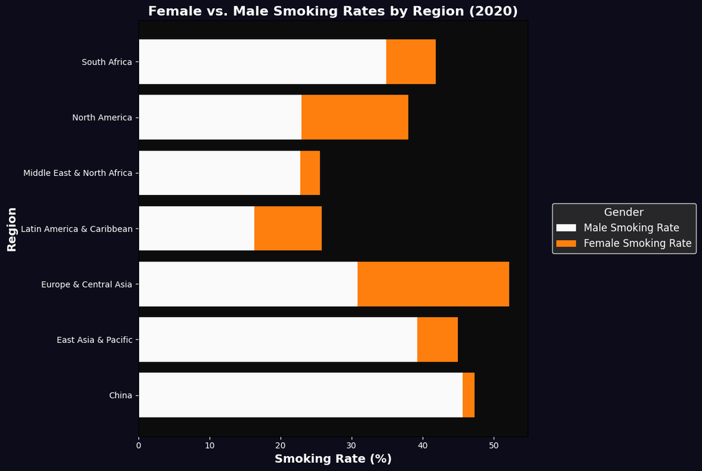

```python
# Prepare the data for the table
fig1_df = region_df[['Male smoking rate in 2020(%)', 'Female smoking rate in 2020(%)']].rename(columns={
    'Male smoking rate in 2020(%)': 'Male Smoking Rate (%)',
    'Female smoking rate in 2020(%)': 'Female Smoking Rate (%)'
})

# Create a horizontal bar chart for Female smoking rate over Male smoking rate
fig, ax = plt.subplots(figsize=(12, 8))

# Plot Male smoking rate bars
male_bars = ax.barh(fig1_df.index, fig1_df['Male Smoking Rate (%)'], color='#fafafa', label='Male Smoking Rate')

# Plot Female smoking rate bars over Male smoking rate
female_bars = ax.barh(fig1_df.index, fig1_df['Female Smoking Rate (%)'],
                      left=fig1_df['Male Smoking Rate (%)'], color='#ff7f0e', label='Female Smoking Rate')

# Customize the chart
ax.set_title('Female vs. Male Smoking Rates by Region (2020)', fontsize=16, weight='bold', color='white')
ax.set_xlabel('Smoking Rate (%)', fontsize=14, weight='bold', color='white')
ax.set_ylabel('Region', fontsize=14, weight='bold', color='white')
ax.set_facecolor('#0c0c0c')  # Inner chart background color
fig.patch.set_facecolor('#0c0c1b')  # Outer background color
ax.tick_params(colors='white')  # Set tick label color to white

# Add legend to the right of the chart with customized font color and background
legend = ax.legend(title='Gender', fontsize=12, title_fontsize=13, loc='center left',
                   bbox_to_anchor=(1.05, 0.5), frameon=True)  # Enable legend frame

# Customize legend background and font colors
legend.get_frame().set_facecolor('#2f2f2f')  # Set background color
legend.get_frame().set_edgecolor('white')    # Set edge color (optional)
legend.get_frame().set_linewidth(1)          # Adjust frame thickness
legend.get_title().set_color('white')        # Set title font color
for text in legend.get_texts():
    text.set_color('white')  # Set label font color

# Adjust layout to prevent clipping
plt.tight_layout()

# Display the chart
plt.show()
```

## Habbits rates between the Regions:

Using the Smoking, Gamers and Coffee data we will normalize them in order for the highest value in each column to be one and in this way scale up each value.

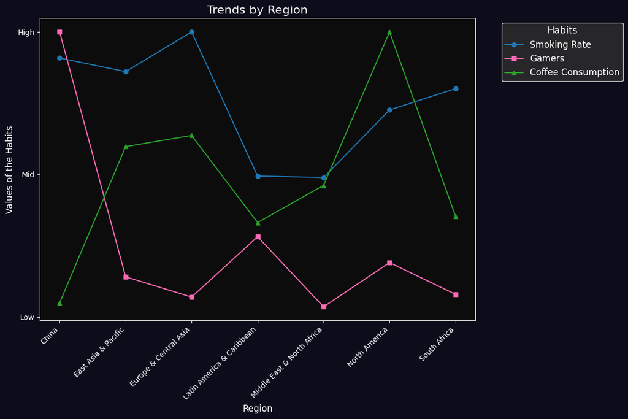

```python
import pandas as pd
import matplotlib.pyplot as plt

# Sample data for the DataFrame (replace this with your existing region_df data)
# region_df = pd.DataFrame({...})  # Use your existing DataFrame here

# Normalize data for comparison
normalized_smoking = region_df['Smoking rate in 2020(%)'] / region_df['Smoking rate in 2020(%)'].max()
normalized_gamers = region_df['Gamers in 2019(MM)'] / region_df['Gamers in 2019(MM)'].max()
normalized_coffee = region_df['Coffee per capita in 2020 (KG)'] / region_df['Coffee per capita in 2020 (KG)'].max()

# Define thresholds for categories
thresholds = {
    'Low': 0.33,
    'Mid': 0.66,
    'High': 1.0
}

# Function to categorize normalized values
def categorize(value):
    if value <= thresholds['Low']:
        return 'Low'
    elif value <= thresholds['Mid']:
        return 'Mid'
    else:
        return 'High'

# Convert normalized values to categories
smoking_categories = normalized_smoking.apply(categorize)
gamers_categories = normalized_gamers.apply(categorize)
coffee_categories = normalized_coffee.apply(categorize)

# Plot multi-line chart
fig, ax = plt.subplots(figsize=(12, 8))

# Plot the lines
ax.plot(region_df.index, normalized_smoking, label='Smoking Rate', marker='o', color='#1f77b4')
ax.plot(region_df.index, normalized_gamers, label='Gamers', marker='s', color='#ff69b4')
ax.plot(region_df.index, normalized_coffee, label='Coffee Consumption', marker='^', color='#2ca02c')

# Customize chart
ax.set_xlabel('Region', fontsize=12, color='white')
ax.set_ylabel('Values of the Habits', fontsize=12, color='white')  # Remove normalized from label
ax.set_title('Trends by Region', fontsize=16, color='white')
ax.set_xticks(range(len(region_df.index)))
ax.set_xticklabels(region_df.index, rotation=45, ha='right', color='white')

# Set background color (inner and outer)
ax.set_facecolor('#0c0c0c')
fig.patch.set_facecolor('#0c0c1b')
ax.tick_params(colors='white')

# Set axis line colors (spines) to white
for spine in ax.spines.values():
    spine.set_color('white')

# Move legend to the right of the plot
legend = ax.legend(loc='upper left', bbox_to_anchor=(1.05, 1), title='Habits', fontsize=12, title_fontsize=13, frameon=True)

# Customize legend background and font colors
legend.get_frame().set_facecolor('#2f2f2f')
legend.get_frame().set_edgecolor('white')
legend.get_frame().set_linewidth(1)
legend.get_title().set_color('white')
for text in legend.get_texts():
    text.set_color('white')

# Adjust y-ticks to be the categories
ax.set_yticks([0, 0.5, 1])  # Set y-ticks to the normalized range
ax.set_yticklabels(['Low', 'Mid', 'High'])  # Convert y-tick labels to categories

# Adjust layout to prevent clipping
plt.tight_layout()

# Display the plot
plt.show()
```

## Habits by region Vs Students by region.

For our last plot we will simply normalize data one more time but this time with different scalability. The main reason is that due to the challenge of different proyected data we have (Rate, Millions and KG) we will have to normalize it all to be able of contrasting the consumption per region.

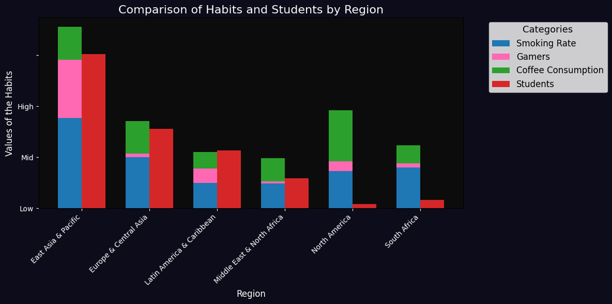

```python
normalized_smoking = region_df['Smoking rate in 2020(%)'] / region_df['Smoking rate in 2020(%)'].max()
normalized_gamers = region_df['Gamers in 2019(MM)'] / region_df['Gamers in 2019(MM)'].max()
normalized_coffee = region_df['Coffee per capita in 2020 (KG)'] / region_df['Coffee per capita in 2020 (KG)'].max()

# Normalize 'Students in 2019-20' to a range from 0 to 3
normalized_students = region_df['Students in 2019-20'] / region_df['Students in 2019-20'].max() * 3

# Create the new DataFrame fig3_df with the normalized values
fig3_df = pd.DataFrame({
    'Normalized Smoking Rate': normalized_smoking,
    'Normalized Gamers': normalized_gamers,
    'Normalized Coffee Consumption': normalized_coffee,
    'Normalized Students': normalized_students
})

# Merge 'China' with 'East Asia & Pacific' by adding their values
fig3_df.loc['East Asia & Pacific'] = fig3_df.loc['China'] + fig3_df.loc['East Asia & Pacific']
fig3_df = fig3_df.drop('China', axis=0)

# Define thresholds for categories
smoking_thresholds = {'Low': 0.33, 'Mid': 0.66, 'High': 1.0}
students_thresholds = {'Low': 1.0, 'Mid': 2.0, 'High': 4.0}

# Function to categorize normalized values
def categorize(value, thresholds):
    if value <= thresholds['Low']:
        return 'Low'
    elif value <= thresholds['Mid']:
        return 'Mid'
    else:
        return 'High'

# Convert normalized values to categories
smoking_categories = fig3_df['Normalized Smoking Rate'].apply(lambda x: categorize(x, smoking_thresholds))
gamers_categories = fig3_df['Normalized Gamers'].apply(lambda x: categorize(x, smoking_thresholds))  # Same thresholds for both
coffee_categories = fig3_df['Normalized Coffee Consumption'].apply(lambda x: categorize(x, smoking_thresholds))  # Same thresholds
students_categories = fig3_df['Normalized Students'].apply(lambda x: categorize(x, students_thresholds))

# Create positions for the bars (the x-axis for the bars)
x = np.arange(len(fig3_df))  # Positions for the bars
width = 0.35  # Width of the bars

# Plotting the stacked bar chart
fig, ax = plt.subplots(figsize=(12, 6))

# Plot each of the habits on top of each other
ax.bar(x, fig3_df['Normalized Smoking Rate'], width, label='Smoking Rate', color='#1f77b4')
ax.bar(x, fig3_df['Normalized Gamers'], width, bottom=fig3_df['Normalized Smoking Rate'], label='Gamers', color='#ff69b4')
ax.bar(x, fig3_df['Normalized Coffee Consumption'], width,
       bottom=fig3_df['Normalized Smoking Rate'] + fig3_df['Normalized Gamers'], label='Coffee Consumption', color='#2ca02c')

# Plot the normalized students next to the stacked habits bar
ax.bar(x + width, fig3_df['Normalized Students'], width, label='Students', color='#d62728')

# Customize chart
ax.set_xlabel('Region', fontsize=12, color='white')
ax.set_ylabel('Values of the Habits', fontsize=12, color='white')  # Change to general label
ax.set_title('Comparison of Habits and Students by Region', fontsize=16, color='white')
ax.set_xticks(x + width / 2)  # Position the labels between bars
ax.set_xticklabels(fig3_df.index, rotation=45, ha='right', color='white')
ax.tick_params(axis='x', colors='white')  # Set the x-axis tick color to white
ax.tick_params(axis='y', colors='white')  # Set the y-axis tick color to white

# Set background color
ax.set_facecolor('#0c0c0c')  # Inner background color
fig.patch.set_facecolor('#0c0c1b')  # Outer background color

# Set y-ticks to be the categories
ax.set_yticks([0, 1, 2, 3])  # We can keep the normalized range for the original value range.
ax.set_yticklabels(['Low', 'Mid', 'High', ''])  # Convert y-tick labels to categories

# Add a legend to the right of the plot
ax.legend(loc='upper left', bbox_to_anchor=(1.05, 1), title='Categories', fontsize=12, title_fontsize=13)

# Adjust layout to avoid clipping
plt.tight_layout()

# Display the plot
plt.show()
```

# Smoking by gender total

This adds and averages all the rows in smoking_df and contrast the smoking impact per gender.

```python
# Compute the average smoking rates for female and male
average_female_smoking = smoking2020_df['Female smoking rate in 2020(%)'].mean()
average_male_smoking = smoking2020_df['Male smoking rate in 2020(%)'].mean()

# Create a DataFrame with the average rates
fig4_df = pd.DataFrame({
    'Smoking Rate': ['Female', 'Male'],
    'Average Rate (%)': [average_female_smoking, average_male_smoking]
}).set_index('Smoking Rate')
```

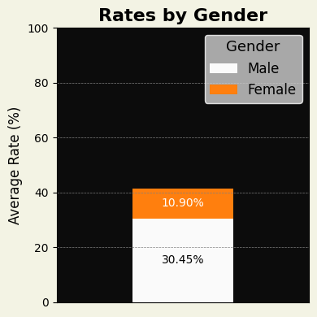

```python
import pandas as pd
import matplotlib.pyplot as plt

# Sample data for the DataFrame (replace this with your existing DataFrame data)
fig4_df = pd.DataFrame({
    'Average Rate (%)': [30.45, 10.90]
}, index=['Male', 'Female'])

# Create the Matplotlib plot
plt.figure(figsize=(4, 4))
plt.gca().set_facecolor('#0c0c0c')
plt.gcf().patch.set_facecolor('#f3f3e4')

# Set positions for the bar plot
male_rates = fig4_df.loc['Male', 'Average Rate (%)']
female_rates = fig4_df.loc['Female', 'Average Rate (%)']

# Plot the stacked bar chart
plt.bar('Rates', male_rates, color='#fafafa', label='Male')
plt.bar('Rates', female_rates, color='#ff7f0e', bottom=male_rates, label='Female')

# Add text annotations
plt.text('Rates', male_rates / 2, f'{male_rates:.2f}%', ha='center', va='center', color='black')
plt.text('Rates', male_rates + female_rates / 2, f'{female_rates:.2f}%', ha='center', va='center', color='white')

# Set y-axis limits
plt.ylim(0, 100)
plt.xlim(-1, 1)

# Customization
plt.title('Rates by Gender', fontsize=16, color='black', weight='bold')
plt.ylabel('Average Rate (%)', fontsize=12, color='black')
plt.xticks([], color='black')
plt.yticks(color='black')
plt.grid(axis='y', color='gray', linestyle='--', linewidth=0.5)

# Add legend manually
legend = plt.legend(
    ['Male', 'Female'],
    loc='upper right',
    title='Gender',
    fontsize=12,
    title_fontsize=13,
    frameon=True
)
legend.get_frame().set_facecolor('#d0d0d0')
legend.get_frame().set_edgecolor('white')
legend.get_frame().set_linewidth(1)
legend.get_title().set_color('black')
for text in legend.get_texts():
    text.set_color('black')

plt.tight_layout()
plt.show()
```

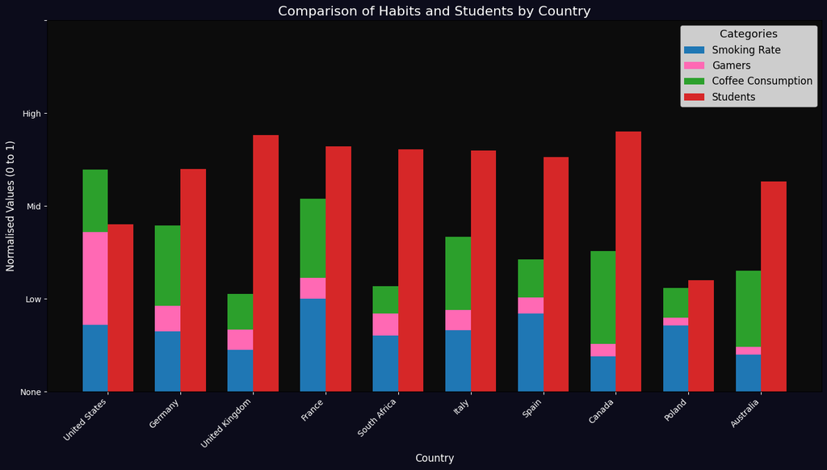

```python
# Normalize the specified columns to a range from 0 to 1 (for all metrics)
normalized_smoking = country_df['Smoking rate in 2020(%)'] / country_df['Smoking rate in 2020(%)'].max()
normalized_gamers = country_df['Gamers in 2019(MM)'] / country_df['Gamers in 2019(MM)'].max()
normalized_coffee = country_df['Coffee per capita in 2020 (KG)'] / country_df['Coffee per capita in 2020 (KG)'].max()

min_target = 1.2  # 30% of 4
max_target = 2.8  # 70% of 4

normalized_students = ((country_df['Students in 2019-20'] - country_df['Students in 2019-20'].min()) /
                       (country_df['Students in 2019-20'].max() - country_df['Students in 2019-20'].min())) * (max_target - min_target) + min_target


# Create a new DataFrame with the normalised values
fig5_df = pd.DataFrame({
    'Normalized Smoking Rate': normalized_smoking,
    'Normalized Gamers': normalized_gamers,
    'Normalized Coffee Consumption': normalized_coffee,
    'Normalized Students': normalized_students
})

# Define thresholds for categories (values normalised between 0 and 1)
thresholds = {'None': 0.0, 'Low': 0.33, 'Mid': 0.66, 'High': 1.0, 'Very High': 1.0}

# Function to categorise the values based on thresholds
def categorize(value, thresholds):
    if value <= thresholds['None']:
        return 'None'
    elif value <= thresholds['Low']:
        return 'Low'
    elif value <= thresholds['Mid']:
        return 'Mid'
    elif value <= thresholds['High']:
        return 'High'
    else:
        return 'Very High'

# Convert normalised values to categories in the DataFrame
fig5_df['Smoking Categories'] = fig5_df['Normalized Smoking Rate'].apply(lambda x: categorize(x, thresholds))
fig5_df['Gamers Categories'] = fig5_df['Normalized Gamers'].apply(lambda x: categorize(x, thresholds))
fig5_df['Coffee Categories'] = fig5_df['Normalized Coffee Consumption'].apply(lambda x: categorize(x, thresholds))
fig5_df['Students Categories'] = fig5_df['Normalized Students'].apply(lambda x: categorize(x, thresholds))

# Create bar positions for the x-axis
x = np.arange(len(fig5_df))  # Create x positions for each country
width = 0.35  # Width for each bar

# Plotting the stacked bar chart
fig, ax = plt.subplots(figsize=(14, 8))

# Plot each normalised habit as a stacked bar
ax.bar(x, fig5_df['Normalized Smoking Rate'], width, label='Smoking Rate', color='#1f77b4')
ax.bar(
    x,
    fig5_df['Normalized Gamers'],
    width,
    bottom=fig5_df['Normalized Smoking Rate'],
    label='Gamers',
    color='#ff69b4'
)
ax.bar(
    x,
    fig5_df['Normalized Coffee Consumption'],
    width,
    bottom=fig5_df['Normalized Smoking Rate'] + fig5_df['Normalized Gamers'],
    label='Coffee Consumption',
    color='#2ca02c'
)

# Plot the normalised students as a separate, adjacent bar
ax.bar(x + width, fig5_df['Normalized Students'], width, label='Students', color='#d62728')

# Customise axes and labels
ax.set_xlabel('Country', fontsize=12, color='white')
ax.set_ylabel('Normalised Values (0 to 1)', fontsize=12, color='white')
ax.set_title('Comparison of Habits and Students by Country', fontsize=16, color='white')
ax.set_xticks(x + width / 2)
ax.set_xticklabels(country_df.index, rotation=45, ha='right', color='white')
ax.tick_params(axis='x', colors='white')
ax.tick_params(axis='y', colors='white')
plt.yticks([0, 1, 2, 3, 4], ['None', 'Low', 'Mid', 'High', ''])


# Set background colors
ax.set_facecolor('#0c0c0c')  # Inner background color
fig.patch.set_facecolor('#0c0c1b')  # Outer background color
# Add a legend inside the chart
ax.legend(loc='upper right', title='Categories', fontsize=12, title_fontsize=13)

# Adjust layout to avoid clipping
plt.tight_layout()

# Display the chart
plt.show()
```

# Habits trend:

```python
# Normalise based on the remaining data
columns_to_normalize = ['Smoking rate in 2020(%)', 'Gamers in 2019(MM)', 'Coffee per capita in 2020 (KG)']
habits_data = habits2020_df[columns_to_normalize]

scaler = MinMaxScaler()
normalized_data = scaler.fit_transform(habits_data)

fig6_df = pd.DataFrame(normalized_data,
                       columns=columns_to_normalize,
                       index=habits_data.index)
# Replace 0.000000 and empty strings with NaN
fig6_df.replace([0.000000, ''], pd.NA, inplace=True)

# Drop rows with any NaN value
fig6_df.dropna(inplace=True)
```

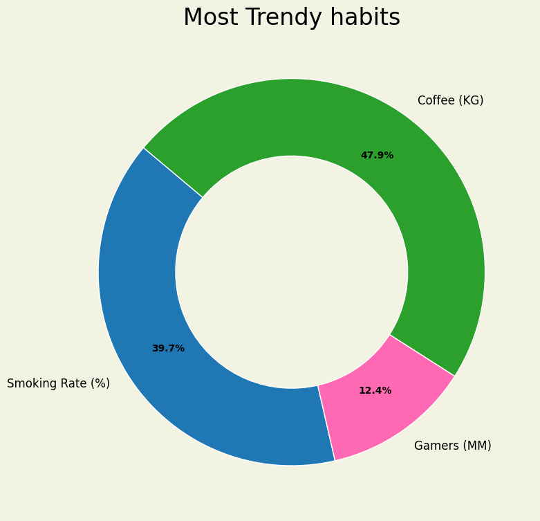

```python
from mpl_toolkits.mplot3d import Axes3D  # Required for 3D effects in pie charts
import matplotlib.pyplot as plt

# Calculate average values for the specified columns
averages = fig6_df[['Smoking rate in 2020(%)', 'Gamers in 2019(MM)', 'Coffee per capita in 2020 (KG)']].mean()

# Create a pie chart with background colour and a smoother 3D-style
fig, ax = plt.subplots(figsize=(8, 8), subplot_kw=dict(aspect="equal"))
fig.patch.set_facecolor('#f3f3e4')  # Set background color

wedges, texts, autotexts = ax.pie(
    averages,
    labels=['Smoking Rate (%)', 'Gamers (MM)', 'Coffee (KG)'],
    autopct='%1.1f%%',
    colors=['#1f77b4', '#ff69b4', '#2ca02c'],
    startangle=140,
    wedgeprops=dict(width=0.4, edgecolor='w'),  # Add 3D/smoother effect
    pctdistance=0.75  # Adjust placement of percentages
)

# Customize text and outline
plt.setp(autotexts, size=10, weight="bold", color="black")
plt.setp(texts, size=12)

ax.set_title("Most Trendy habits", fontsize=24)

plt.tight_layout()
plt.show()
```

# Habits per country

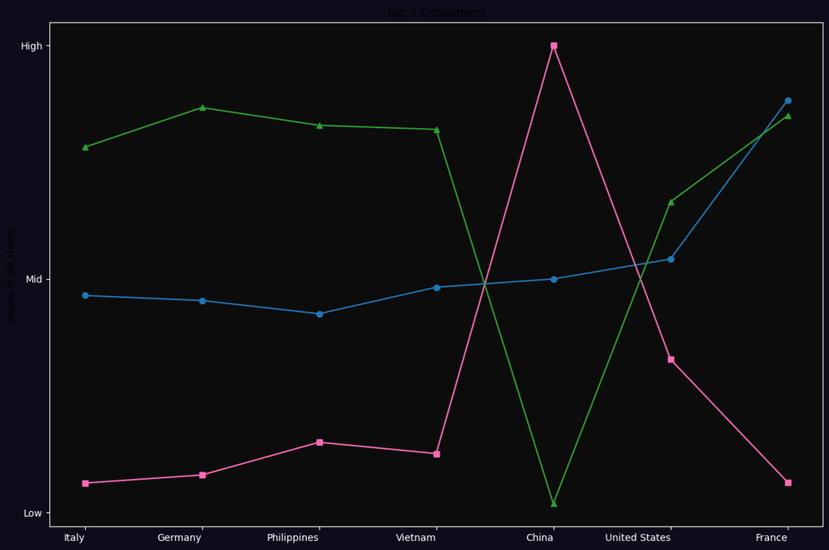

```python
# Prepare the data
fig7_df = (fig6_df.copy()
           .assign(Rank=lambda df: df[['Smoking rate in 2020(%)', 'Gamers in 2019(MM)', 'Coffee per capita in 2020 (KG)']].mean(axis=1))
           .sort_values('Rank').tail(7)) #change this to constrol how many countries to dislpay

# Extract normalized data
normalized_smoking, normalized_gamers, normalized_coffee = (
    fig7_df['Smoking rate in 2020(%)'],
    fig7_df['Gamers in 2019(MM)'],
    fig7_df['Coffee per capita in 2020 (KG)']
)

# Create the plot
fig, ax = plt.subplots(figsize=(12, 8))
ax.plot(fig7_df.index, normalized_smoking, label='Smoking Rate', marker='o', color='#1f77b4')
ax.plot(fig7_df.index, normalized_gamers, label='Gamers', marker='s', color='#ff69b4')
ax.plot(fig7_df.index, normalized_coffee, label='Coffee Consumption', marker='^', color='#2ca02c')

# Customise labels, title, and styling
ax.set(xlabel='', ylabel='Values of the Habits', title='Top 7 Consumers')
ax.set_xticks(range(len(fig7_df.index)))
ax.set_xticklabels(fig7_df.index, rotation=0, ha='right', color='white')
ax.set_yticks([0, 0.5, 1])
ax.set_yticklabels(['Low', 'Mid', 'High'])

# Styling adjustments
ax.set_facecolor('#0c0c0c')
fig.patch.set_facecolor('#0c0c1b')
ax.tick_params(colors='white')
for spine in ax.spines.values():
    spine.set_color('white')

# Final layout and display
plt.tight_layout()
plt.show()
```

# Heatmap

Using GIMP I'll make a region map of habits using my poor geographic knowledge and a our Region graph in fig 3

[figure not shown]

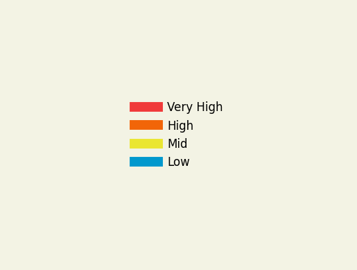

```python
import matplotlib.pyplot as plt

# Create the legend with the given colours and labels
colors = ['#f03a3a', '#f26508', '#eae631', '#0198cd']
labels = ['Very High', 'High', 'Mid', 'Low']

# Generate a blank plot for the custom legend
fig, ax = plt.subplots()
for color, label in zip(colors, labels):
    ax.plot([], [], color=color, label=label, linewidth=10)

# Add the legend
ax.legend(loc='center', frameon=False, ncol=1, fontsize=12)
plt.gcf().patch.set_facecolor('#f3f3e4')

# Remove axes for clarity
ax.axis('off')

# Display the plot
plt.show()
```

# Podium

Using fig6_df we will recreate 'Rank' for displaying the top 5 Countries with the lowest amount of habits.

```
               Smoking rate in 2020(%) Gamers in 2019(MM)  \
Country
Iran                          0.152482           0.035054
Thailand                      0.358156           0.065743
United Kingdom                0.212766           0.060523
Brazil                        0.117021           0.272652
South Africa                  0.400709           0.068116

               Coffee per capita in 2020 (KG)      Rank   Rank (%)
Country
Iran                                 0.020468  0.069335   6.933484
Thailand                              0.04386   0.15592  15.591951
United Kingdom                       0.368421  0.213903  21.390322
Brazil                               0.260234  0.216636   21.66359
South Africa                          0.27924  0.249355  24.935488
```

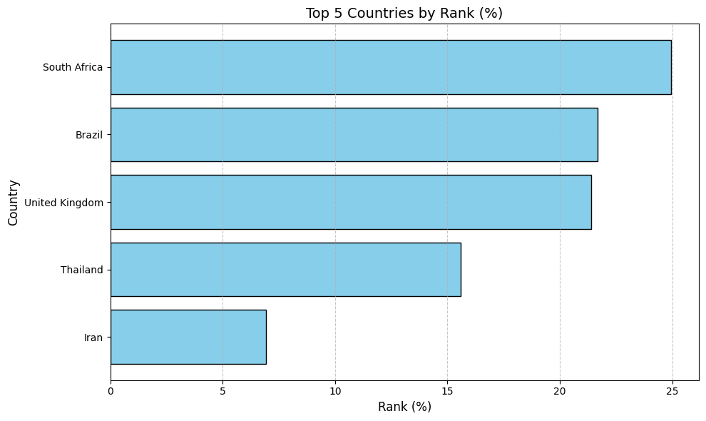

```python
# Prepare the data
fig9_df = fig6_df.copy()  # Copy normalized data into fig9_df

# Adding a new column "Rank" that calculates the average of the specified columns across rows
fig9_df['Rank'] = fig9_df[['Smoking rate in 2020(%)', 'Gamers in 2019(MM)', 'Coffee per capita in 2020 (KG)']].mean(axis=1)

# Sorting fig9_df by the "Rank" column in ascending order and taking the first 7 rows
fig9_df = fig9_df.sort_values(by='Rank', ascending=True).head(5)

# Convert Rank to percentage (scale 0-100)
fig9_df['Rank (%)'] = fig9_df['Rank'] * 100

print(fig9_df)
# Quick plot to visualise fig9_df
plt.figure(figsize=(10, 6))
plt.barh(fig9_df.index, fig9_df['Rank (%)'], color='skyblue', edgecolor='black')
plt.xlabel('Rank (%)', fontsize=12)
plt.ylabel('Country', fontsize=12)
plt.title('Top 5 Countries by Rank (%)', fontsize=14)
plt.grid(axis='x', linestyle='--', alpha=0.7)

plt.tight_layout()
plt.show()
```